# BIOL 416 R Tutorial 1 - Introduction to R

### Histograms

Let’s start with something simple - a histogram of `Sepal.Length`?

We need to first tell R where to find the data we want to plot - we want to tell R that it can find a column of data called `Sepal.Length` inside of the `iris` data-frame. Take a minute to recall how we can do this - how do we tell R where to find our `Sepal.Length` data?

```r
# There are two ways we can do this
## Because the iris data has columns with names, we can use the name of the column we want
iris$Sepal.Length
```

```
##   [1] 5.1 4.9 4.7 4.6 5.0 5.4 4.6 5.0 4.4 4.9 5.4 4.8 4.8 4.3 5.8 5.7 5.4
##  [18] 5.1 5.7 5.1 5.4 5.1 4.6 5.1 4.8 5.0 5.0 5.2 5.2 4.7 4.8 5.4 5.2 5.5
##  [35] 4.9 5.0 5.5 4.9 4.4 5.1 5.0 4.5 4.4 5.0 5.1 4.8 5.1 4.6 5.3 5.0 7.0
##  [52] 6.4 6.9 5.5 6.5 5.7 6.3 4.9 6.6 5.2 5.0 5.9 6.0 6.1 5.6 6.7 5.6 5.8
##  [69] 6.2 5.6 5.9 6.1 6.3 6.1 6.4 6.6 6.8 6.7 6.0 5.7 5.5 5.5 5.8 6.0 5.4
##  [86] 6.0 6.7 6.3 5.6 5.5 5.5 6.1 5.8 5.0 5.6 5.7 5.7 6.2 5.1 5.7 6.3 5.8
## [103] 7.1 6.3 6.5 7.6 4.9 7.3 6.7 7.2 6.5 6.4 6.8 5.7 5.8 6.4 6.5 7.7 7.7
## [120] 6.0 6.9 5.6 7.7 6.3 6.7 7.2 6.2 6.1 6.4 7.2 7.4 7.9 6.4 6.3 6.1 7.7
## [137] 6.3 6.4 6.0 6.9 6.7 6.9 5.8 6.8 6.7 6.7 6.3 6.5 6.2 5.9
```

```r
## We can always use numbers-based indexing as well
iris[,1]
```

```
##   [1] 5.1 4.9 4.7 4.6 5.0 5.4 4.6 5.0 4.4 4.9 5.4 4.8 4.8 4.3 5.8 5.7 5.4
##  [18] 5.1 5.7 5.1 5.4 5.1 4.6 5.1 4.8 5.0 5.0 5.2 5.2 4.7 4.8 5.4 5.2 5.5
##  [35] 4.9 5.0 5.5 4.9 4.4 5.1 5.0 4.5 4.4 5.0 5.1 4.8 5.1 4.6 5.3 5.0 7.0
##  [52] 6.4 6.9 5.5 6.5 5.7 6.3 4.9 6.6 5.2 5.0 5.9 6.0 6.1 5.6 6.7 5.6 5.8
##  [69] 6.2 5.6 5.9 6.1 6.3 6.1 6.4 6.6 6.8 6.7 6.0 5.7 5.5 5.5 5.8 6.0 5.4
##  [86] 6.0 6.7 6.3 5.6 5.5 5.5 6.1 5.8 5.0 5.6 5.7 5.7 6.2 5.1 5.7 6.3 5.8
## [103] 7.1 6.3 6.5 7.6 4.9 7.3 6.7 7.2 6.5 6.4 6.8 5.7 5.8 6.4 6.5 7.7 7.7
## [120] 6.0 6.9 5.6 7.7 6.3 6.7 7.2 6.2 6.1 6.4 7.2 7.4 7.9 6.4 6.3 6.1 7.7
## [137] 6.3 6.4 6.0 6.9 6.7 6.9 5.8 6.8 6.7 6.7 6.3 6.5 6.2 5.9
```

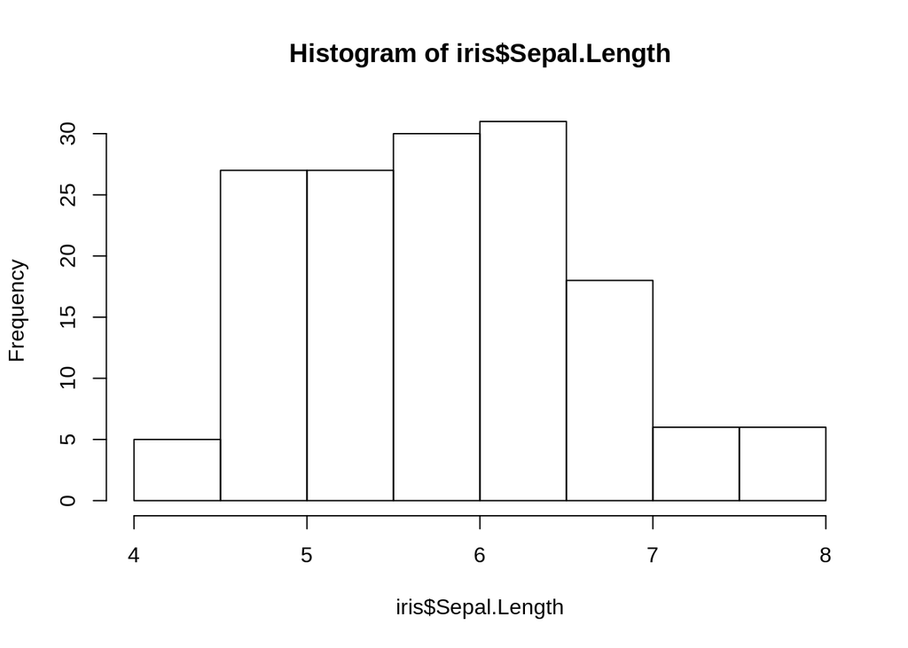

```r
# To make the plot:
hist(iris$Sepal.Length)
```

Easy, wasn’t it? But it isn’t very pretty - what could we change?

When we make modifications to our plot, we pass extra arguments. In the original command, `hist(iris$Sepal.Length)`, the only argument we gave it was the data to plot.

Take a look at what other arguments are available with `?hist()`:

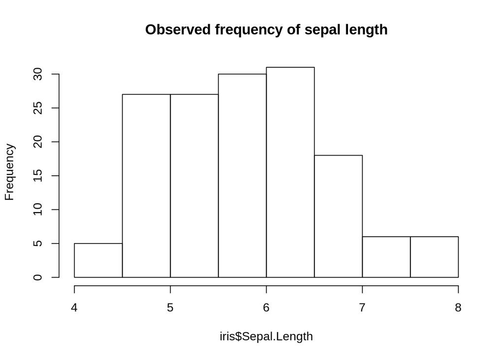

```r
?hist()

# Change the title, NOTICE THAT WE USE COMMAS AND ARGUMENT NAMES!!!
hist(x = iris$Sepal.Length, main = "Observed frequency of sepal length")
```

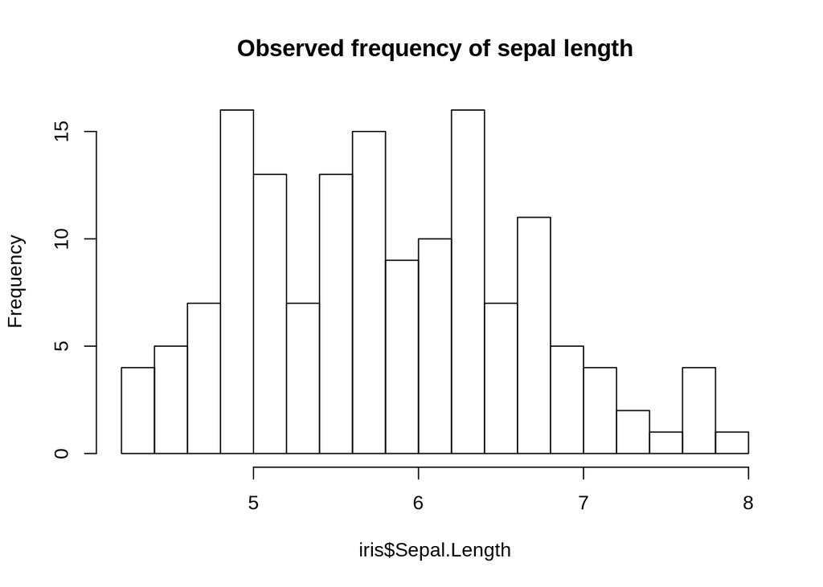

```r
hist(x = iris$Sepal.Length, main = "Observed frequency of sepal length", breaks = 20)
```

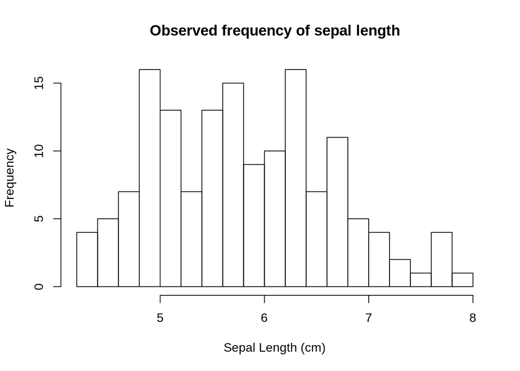

```r
hist(iris$Sepal.Length,
     main = "Observed frequency of sepal length",
     breaks = 20,
     xlab = "Sepal Length (cm)")
```

### Scatterplot

What about a more complicated type of plot next?

Let’s try an x-y/scatter plot:

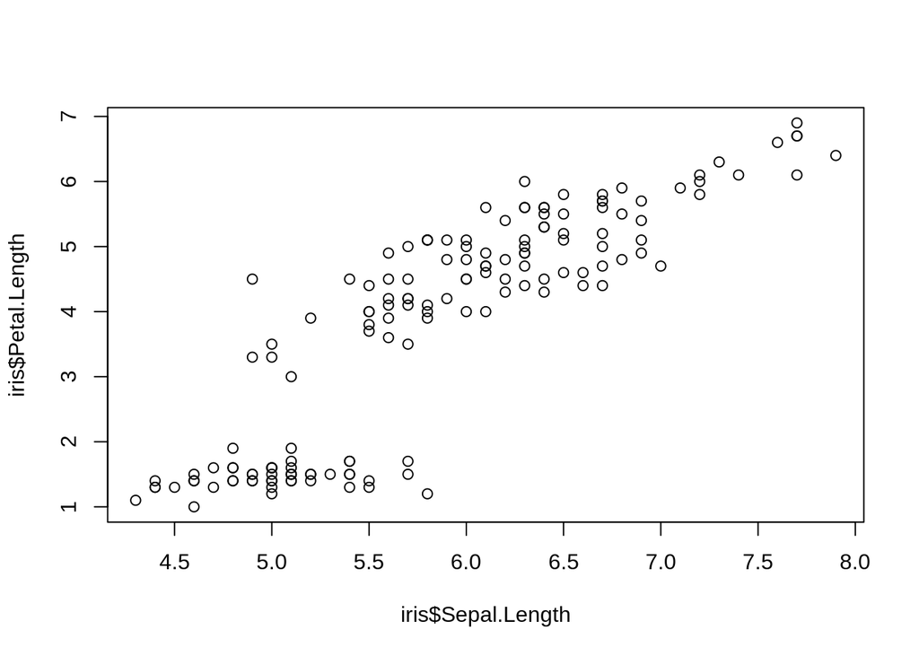

```r
?plot()

plot(x = iris$Sepal.Length,
     y = iris$Petal.Length)
```

Take five minutes to change the main title and the X and Y axes’ titles.

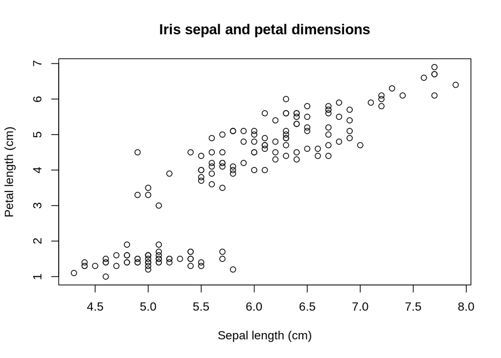

```r
# Output should look something like this
plot(x = iris$Sepal.Length,
     y = iris$Petal.Length,
     main = "Iris sepal and petal dimensions",
     ylab = "Petal length (cm)",
     xlab = "Sepal length (cm)")
```

We can also goof around with colors and point types:

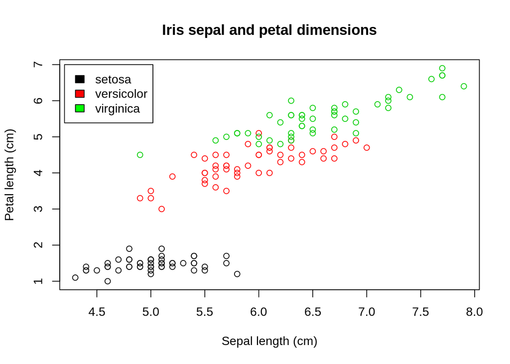

```r
plot(x = iris$Sepal.Length,
     y = iris$Petal.Length,
     main = "Iris sepal and petal dimensions",
     ylab = "Petal length (cm)",
     xlab = "Sepal length (cm)",
     col = iris$Species)
#     pch = 19)

# And we can add a legend:
legend(x = 4.2,
       y = 7,
       legend = unique(iris$Species),
       fill = c('black','red','green'))
```

### Saving plots

Plots that you create in R can be saved in one of two ways:

1. Saving in the `Plots` tab in the lower right panel
2. Saving directly in the code - most useful if you’re going to be recreating the plots a bunch

Here’s how you save the image with code:

```r
# Saving plots with code:
## For example, to save a .png:
png("iris_scatterplot.png")
plot(x = iris$Sepal.Length,
     y = iris$Petal.Length,
     main = "Iris sepal and petal dimensions",
     ylab = "Petal length (cm)",
     xlab = "Sepal length (cm)",
     col = iris$Species,
     pch = 19)
dev.off()
```

This uses two new functions:

You can also save to other formats:

```r
pdf("iris_scatterplot.pdf")
plot(x = iris$Sepal.Length,
     y = iris$Petal.Length,
     main = "Iris sepal and petal dimensions",
     ylab = "Petal length (cm)",
     xlab = "Sepal length (cm)",
     col = iris$Species,
     pch = 19)
dev.off()
```

```r
# Or pass arguments about the plot itself, like the size, resolution, etc.
png("iris_scatterplot_smaller.png", width = 200, height = 200)
plot(x = iris$Sepal.Length,
     y = iris$Petal.Length,
     main = "Iris sepal and petal dimensions",
     ylab = "Petal length (cm)",
     xlab = "Sepal length (cm)",
     col = iris$Species,
     pch = 19)
dev.off()
```

Here’s another type of plot - try to make this one on your own.

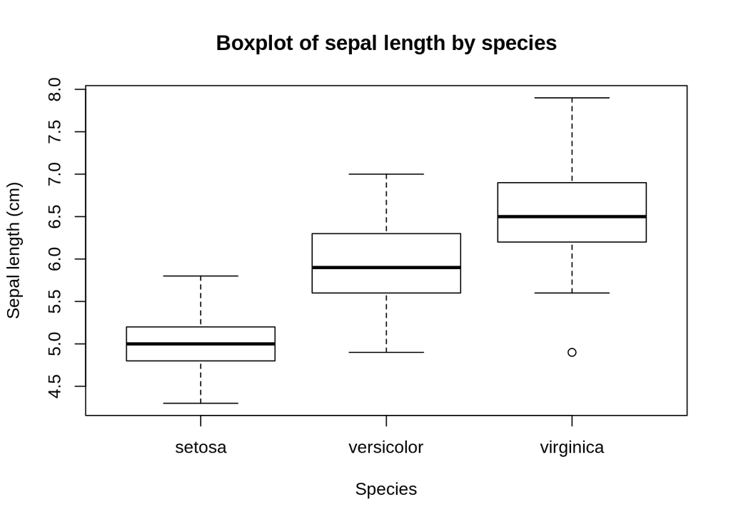

```r
?boxplot()

boxplot(iris$Sepal.Length~iris$Species, fill=iris$Species,
        main = "Boxplot of sepal length by species",
        ylab = "Sepal length (cm)",
        xlab = "Species"
)
```

### Intro to statistics - linear regression

The final thing that R is particularly good at besides plotting data performing statistics on those data.

Let’s start with something really simple - what if we want to know how correlated sepal length and petal length are in these three species of iris? This is also useful for overlaying a line on top of our scatterplot.

The tool that we want is called linear regression using a new function, `lm()`.

`lm()` stands for linear model - this function fits a linear regression between two variables. Essentially, linear regression is used to calculate how closely correlated one variable is to another.

The linear part refers to the fact that we are calculating a straight-line relationship between these two, just like in the classic linear equation:
$$y = mx+b$$

If our $x$ is sepal length and our $y$ is petal length, we want to create an equation that we can use to predict petal length based on some observed sepal length.

In other words, we’re asking “when observed sepal length increases, how much of an increase in petal length should we expect?” We probably also want to know if there is a statistically significant relationship between the two, or if the trend we see in this plot could arise from random noise in our data.

Linear regression finds the values for $m$, the slope of the relationship, and $b$, the y-intercept of the line, that best predict petal length from sepal length.

We’re not going to go too much further into the statistical basis for this, so let’s just dive into the code.

```r
# Regress petal length against sepal length

?lm()

# lm() looks for a formula; in other words, we need to provide an equation for what variables we expect to be dependent on the other.
# In this case, let's assume that we are testing the petal length as a function of sepal length.

# NOTE: new argument, data =, allows us to use just the variable names directly

linear.model <- lm(Petal.Length~Sepal.Length,
   data = iris)

summary(linear.model)
```

```
##
## Call:
## lm(formula = Petal.Length ~ Sepal.Length, data = iris)
##
## Residuals:
##      Min       1Q   Median       3Q      Max
## -2.47747 -0.59072 -0.00668  0.60484  2.49512
##
## Coefficients:
##              Estimate Std. Error t value Pr(>|t|)
## (Intercept)  -7.10144    0.50666  -14.02   <2e-16 ***
## Sepal.Length  1.85843    0.08586   21.65   <2e-16 ***
## ---
## Signif. codes:  0 '***' 0.001 '**' 0.01 '*' 0.05 '.' 0.1 ' ' 1
##
## Residual standard error: 0.8678 on 148 degrees of freedom
## Multiple R-squared:   0.76,  Adjusted R-squared:  0.7583
## F-statistic: 468.6 on 1 and 148 DF,  p-value: < 2.2e-16
```

Using the `summary()` command, R will spit out a bunch of information about the results of our linear regression.

For example, the coefficient for `Sepal.Length` is 1.85843 - this is the $m$ value in our classical linear equation. Meanwhile, the estimate for our y-intercept is -7.10144. Putting these into our equation, we can say that the best linear equation to describe the relationship between petal length and sepal length is:

$$Petal.Length = 1.85843*Sepal.Length -7.10144$$
Now that we have this line, we can put it on top of our scatter plot!

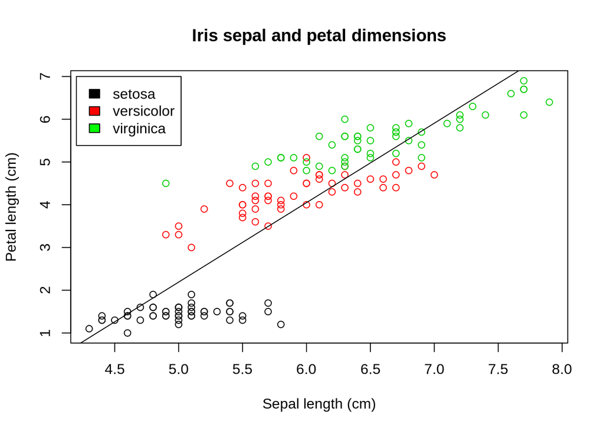

```r
# the abline() function can be used to directly put linear model objects onto a plot
plot(x = iris$Sepal.Length,
     y = iris$Petal.Length,
     main = "Iris sepal and petal dimensions",
     ylab = "Petal length (cm)",
     xlab = "Sepal length (cm)",
     col = iris$Species)# ,
     #pch = 19)
abline(linear.model)
legend(x = 4.2,
       y = 7,
       legend = unique(iris$Species),
       fill = c('black','red','green'))
```